# Unit5

## Unit 5

#### Inference for Categorical Variables.

Parameter of interest is a proportion.

### Part 1

#### Sampling Variability and the CLT for Proportions

##### CLT for proportions

The distribution of sample proportions is nearly normal, centered at the population proportion, and with a standard error inversely proportional to the sample size.

${SE = \sqrt{\dfrac{p(1-p)}{n}} }$

${ mean = p }$

${\hat{p} \tilde{} N (mean, SE) }$

##### Conditions for the CLT.

1. Independence.
2. Sample size/skew: There should be at least 10 successes and 10 failures in the sample: ${ np \geq 10 }$ and ${ n(1-p) \geq 10 }$

If p is unknown, use ${ \hat{p} }$

```r
p = 0.90;
n = 200;

if (n * p < 10 || n * (1-p) < 10)
  "Cannot use this method";

mean=p;
SE=sqrt(p*(1-p)/n);
Z=(0.95 - mean)/SE;
pvalue=1-pnorm(Z);
# pvalue=1-pnorm(0.95, mean, SE); Alternative.

sprintf("SE=%.4f, Z=%.4f, pvalue=%.8f",SE, Z, pvalue);
```

```
## [1] "SE=0.0212, Z=2.3570, pvalue=0.00921106"
```

#### Confidence Interval for a Proportion

##### Estimating a proportion

point estimate ${\pm}$ margin of error

${ \hat{p} \pm z\star SE_{\hat{p}} }$

##### Standard Error for a proportion

${SE_{\hat{p}} = \sqrt{\dfrac{\hat{p}(1-\hat{p})}{n}} }$

```r
p = 0.85;
n = 670;
SE=sqrt(p*(1-p)/n);
mean=p;
me = 1.96*SE;
sprintf("mean=%.4f, SE=%.4f, (%.4f, %.4f)",p,SE,mean - me, mean + me);
```

```
## [1] "mean=0.8500, SE=0.0138, (0.8230, 0.8770)"
```

##### Calculating the required sample size for desired ME.

${ ME = z^\star\sqrt{\dfrac{\hat{p}(1-\hat{p})}{n}} }$

If there is a previous study that we can rely on for the value of ${ \hat{p} }$ use that in the calculation of the required sample size.

If not, use ${ \hat{p} = 0.5 }$

#### Hypothesis Test for a Proportion.

1. Set the hypothesis:
- ${H_0: p = null value }$
- ${H_A: p < }$ or ${ > }$ or ${ \ne }$ null value
2. Check conditions:
- Independence.
- Sample size/skew. ${ np \geq 10 }$ and ${ n(1-p) \geq 10 }$
3. Draw sampling distribution, shade p-value, calculate test statistic.

${ Z = \dfrac{\hat{p} - p}{SE} }$, ${SE = \sqrt{\dfrac{p(1-p)}{n}} }$

4. Make a decision, and interpret it in context of the research question:
- If p-value < ${ \alpha }$, reject ${H_0}$; The data provide convincing evidence for ${H_A}$.
- If p-value > ${ \alpha }$, fail to reject ${H_0}$; the data do not provide convincing evidence for ${H_A}$.

##### When do we use ${\hat{p} }$ vs ${p}$

- Use ${\hat{p}}$ when you don’t have ${p}$.
- Confidence intervals. Use ${\hat{p}}$.
- Hypothesis test. Use ${p}$.

```r
p = 0.5;
phat = 0.6;
n = 1983
alpha=0.05;

SE=sqrt(p*(1-p)/n);
Z= (phat - p)/SE;

pvalue=1 - pnorm(Z);
sprintf("SE=%.4f, Z=%.4f, pvalue=%.4f, rejectH0=%s", SE, Z, pvalue, (pvalue < alpha));
```

```
## [1] "SE=0.0112, Z=8.9062, pvalue=0.0000, rejectH0=TRUE"
```

### Part 2

#### Estimating the Difference Between Two Proportions.

point estimate ${\pm}$ margin of error

${(\hat{p}_1 - \hat{p}_2 ) \pm z\star SE_{(\hat{p}_1 - \hat{p}_2 )} }$

${ SE = \sqrt{ \dfrac{\hat{p}_1(1 - \hat{p}_1)}{n_1} + \dfrac{\hat{p}_2(1 - \hat{p}_2)}{n_2}} }$

##### Conditions for inference

1. Independent
- Within gropups.
- Between groups.
2. Sample skew.
- ${ n_1p_1 \geq 10 }$ and ${ n_1(1-p_1) \geq 10 }$
- ${ n_2p_2 \geq 10 }$ and ${ n_2(1-p_2) \geq 10 }$

```r
p1 = .71;
n1 = 83;
p2 = .25
n2 = 1028;

pe = p1 - p2; # point estimate.
SE = sqrt(p1*(1-p1)/n1 + p2*(1-p2)/n2);
me = 1.96 * SE;

sprintf("pe=%.4f, SE=%.4f, (%.4f, %.4f)", pe, SE, pe - me, pe + me);
```

```
## [1] "pe=0.4600, SE=0.0516, (0.3589, 0.5611)"
```

#### Hypothesis Test for Comparing Two Proportions.

##### Pooled proportion

${ \hat{p_{pool}} = \dfrac{\text{# of successes}_1 + \text{# of successes}_2}{n_1 + n_2} }$

##### Success-failure condition.

${n_1\hat{p_{pool}} \geq 10}$

${n_1(1 - \hat{p_{pool}}) \geq 10}$

${n_2\hat{p_{pool}} \geq 10}$

${n_2(1 - \hat{p_{pool}}) \geq 10}$

##### Standard Error

${ SE = \sqrt{ \dfrac{\hat{p}_{pool}(1 - \hat{p}_{pool})}{n_1} + \dfrac{\hat{p}_{pool}(1 - \hat{p}_{pool})}{n_2}} }$

```r
s1 = 34;
s2 = 61;
p1=0.38;
p2=0.50;
n1 = 90;
n2 = 122;

pool = (s1 + s2)/(n1 + n2);

if (n1*pool < 10)  "success-failure condition failed";
if (n1*(1 - pool) < 10)  "success-failure condition failed";
if (n2*pool < 10) "success-failure condition failed";
if (n2*(1 - pool) < 10)  "success-failure condition failed";

pe = p1 - p2; # point estimate.
SE = sqrt(pool*(1-pool)/n1 + pool*(1-pool)/n2);
z = (pe - 0)/SE;
pvalue=(1 - pnorm(abs(z))) * 2;
sprintf("pe=%.4f, SE=%.4f, z=%.4f, pvalue=%.4f, rejectH0=%s", pe, SE, z, pvalue, pvalue < 0.05);
```

```
## [1] "pe=-0.1200, SE=0.0691, z=-1.7366, pvalue=0.0825, rejectH0=FALSE"
```

### Part 3

#### Small Sample Proportion

- What if success-failure condition is not met?
- Inference via simulation.
- Setting up a simultation assuming ${H_0}$ is true.

##### Paul the Octopus example

###### Set up hypothesis

${H_0 : p = 0.5}$

${H_A: p > 0.5 }$

${ n = 8 }$

${ \hat{p} = 1 }$

###### Check conditions.

1. Independence. (Met)
2. Sample size/skew. (Not met)

###### Inference via simulations.

- Devise a simulation scheme that assumes the null hypothesis is true.
- Repeat the simulation many times and record relevant sample statistic.
- Calculate p-value as the proportion of simulations that yield a result favorable to the alternative hypothesis.

```r
source("http://bit.ly/dasi_inference")
paul = factor(c(rep("yes", 8), rep("no",0)), levels = c("yes", "no"))
inference(paul, est = "proportion", type="ht", method="simulation", success="yes", null = 0.5, alternative ="greater")
```

```
## Single proportion -- success: yes
## Summary statistics:
```

```
## p_hat = 1 ;  n = 8
## H0: p = 0.5
## HA: p > 0.5
```

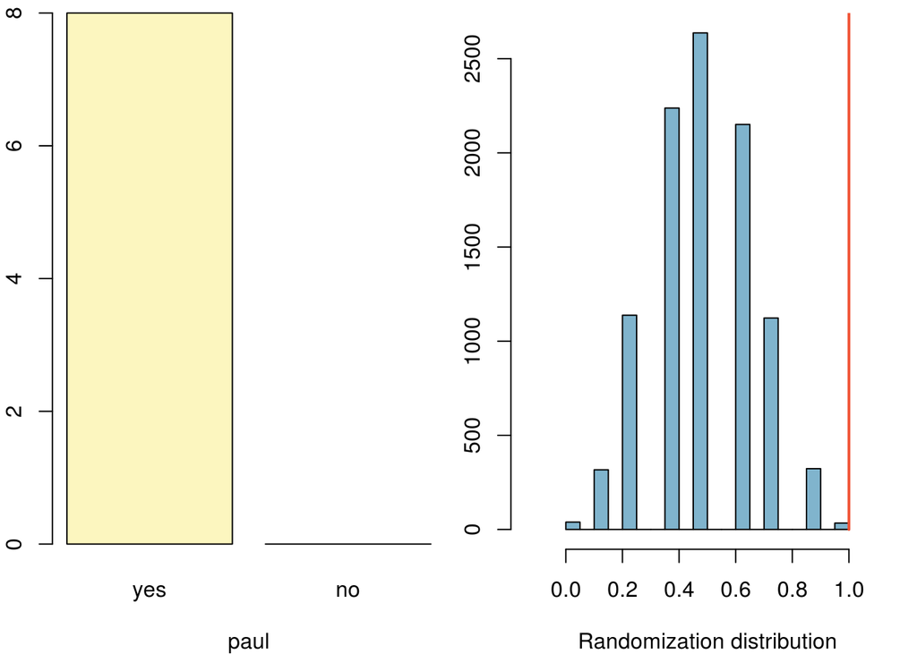

```
## p-value =  0.0034
```

#### Back hand example

```r
source("http://bit.ly/dasi_inference")
back = factor(c(rep("correct", 11), rep("incorrect", 1)))
inference(back, est = "proportion", type="ht", method="simulation", success="correct", null = 0.1, alternative ="greater", nsim=100)
```

```
## Single proportion -- success: correct
## Summary statistics:
```

```
## p_hat = 0.9167 ;  n = 12
## H0: p = 0.1
## HA: p > 0.1
```

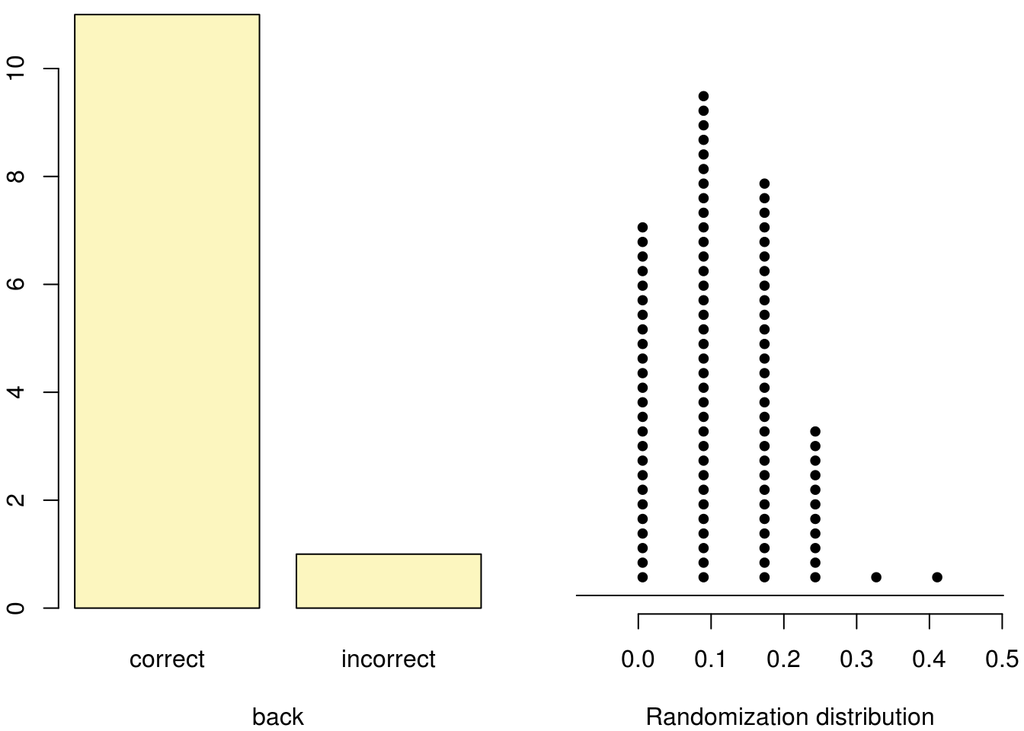

```
## p-value =  0
```

#### Comparing two small sample proportions

${H_0 : P_1 - P_2 = 0 }$

${ H_A: P_1 - P_2 \ne 0 }$

##### Conditions for inference

1. Independent
- Within gropups.
- Between groups.
2. Sample skew.
- ${ n_1p_1 \geq 10 }$ and ${ n_1(1-p_1) \geq 10 }$
- ${ n_2p_2 \geq 10 }$ and ${ n_2(1-p_2) \geq 10 }$

### Part 4

#### Chi-Square Goodness of Fit Test

Evaluate the distribution of **One Categorical Variable**, > 2 levels.

##### Conditions for the chi-square test:

1. Independence
- Random sample/assignment.
- n < 10% of population.
- Each case only contributes to one cell in the table.
2. Sample Size: Each particular scenario (i.e cell) must have at least 5 expected cases.

##### The chi-square statistic

When dealing with counts and investigation how far the observed counts are from the expected counts, we use a new test statistic called the **chi-square( ${\chi^2 }$ )**

${ \chi^2 = \sum\limits_{i=1}^{k} \dfrac{(O - E)^2}{E} }$

- O : Observed.
- E : Expected.
- k : number of cells.

##### Degrees of freedom (df)

Influences the shape, center and spread.

${df = k -1 }$

```r
o = c(1920, 347, 19, 84, 130);
e = c(2007, 302, 20, 73, 98);
k = length(o);
chis = sum((o-e)^2/e);
df = k -1;
pvalue=pchisq(chis, df, lower.tail=FALSE);
sprintf("chis=%.4f, df=%.4f, pvalue=%.4f, rejectH0=%s", chis, df, pvalue, (pvalue < 0.05));
```

```
## [1] "chis=22.6331, df=4.0000, pvalue=0.0001, rejectH0=TRUE"
```

#### The Chi-Square Independence Test

Evaluate the distribution of **Two Categorical Variable**, at least one with > 2 levels.

${ \chi^2 = \sum\limits_{i=1}^{k} \dfrac{(O - E)^2}{E} }$

${df = (R - 1) * (C - 1) }$

- O : Observed.
- E : Expected.
- R : number of rows.
- C : number of columns.

${ \text{expected count} = \dfrac{( \text{row total} * \text{column total} )}{\text{table total} } }$

```r
o = c(81, 103, 147, 359, 326, 277);
e = c(113, 110, 108, 327, 319, 316);
R = 2;
C = 3;
k = length(o);
chis = sum((o-e)^2/e);
df = (R - 1) * (C -1);
pvalue=pchisq(chis, df, lower.tail=FALSE);
sprintf("chis=%.4f, df=%.4f, pvalue=%.4f, rejectH0=%s", chis, df, pvalue, (pvalue < 0.05));
```

```
## [1] "chis=31.6891, df=2.0000, pvalue=0.0000, rejectH0=TRUE"
```